# Project 2: Saturday Data

## Modeling

First, I will split the data into training and test sets. The training data set will contain 70% of the data observations, and the test set will contain the remaining 30%.

Dimensions of the train and test sets:

```
## [1] 1717   46

## [1] 736  46
```

### Linear Model

I will first begin by fitting a linear regression model with ALL of the variables.

```
##
## Call:
## lm(formula = shares ~ ., data = dTrain)
##
## Residuals:
##    Min     1Q Median     3Q    Max
## -16813  -3141  -1259    804 599709
##
## Coefficients: (1 not defined because of singularities)
##                                 Estimate Std. Error t value Pr(>|t|)
## (Intercept)                    5.760e+02  5.568e+03   0.103  0.91762
## n_tokens_title                 3.086e+02  2.028e+02   1.521  0.12835
## n_tokens_content              -1.299e+00  1.445e+00  -0.899  0.36892
## n_unique_tokens               -7.903e+03  1.417e+04  -0.558  0.57715
## n_non_stop_words               1.469e+03  1.169e+04   0.126  0.89998
## n_non_stop_unique_tokens       2.078e+03  1.192e+04   0.174  0.86160
## num_hrefs                      3.486e+01  4.357e+01   0.800  0.42384
## num_self_hrefs                -1.202e+02  9.246e+01  -1.300  0.19364
## num_imgs                       1.450e+01  5.789e+01   0.250  0.80228
## num_videos                    -6.599e+00  1.144e+02  -0.058  0.95401
## average_token_length           3.981e+02  1.799e+03   0.221  0.82483
## num_keywords                   1.403e+02  2.586e+02   0.543  0.58753
## data_channel_is_lifestyle     -4.219e+03  1.989e+03  -2.121  0.03404 *
## data_channel_is_entertainment -4.460e+03  1.665e+03  -2.678  0.00748 **
## data_channel_is_bus           -3.207e+03  1.983e+03  -1.617  0.10603
## data_channel_is_socmed        -4.873e+03  2.195e+03  -2.220  0.02657 *
## data_channel_is_tech          -4.306e+03  1.724e+03  -2.497  0.01262 *
## data_channel_is_world         -5.155e+03  1.905e+03  -2.706  0.00688 **
## kw_min_min                     2.370e+01  1.214e+01   1.952  0.05111 .
## kw_max_min                    -1.463e-01  7.669e-01  -0.191  0.84873
## kw_avg_min                     1.835e-01  4.642e+00   0.040  0.96847
## kw_min_max                     6.196e-03  8.159e-03   0.759  0.44770
## kw_max_max                    -6.155e-04  4.475e-03  -0.138  0.89062
## kw_avg_max                    -6.724e-03  6.206e-03  -1.083  0.27875
## kw_min_avg                     5.243e-01  5.041e-01   1.040  0.29852
## kw_max_avg                    -3.328e-02  1.641e-01  -0.203  0.83930
## kw_avg_avg                     4.455e-01  9.891e-01   0.450  0.65245
## self_reference_min_shares      6.434e-02  8.856e-02   0.727  0.46760
## self_reference_max_shares      5.803e-03  4.611e-02   0.126  0.89987
## self_reference_avg_sharess     2.529e-02  1.163e-01   0.217  0.82794
## global_subjectivity           -6.853e+03  6.215e+03  -1.103  0.27026
## global_sentiment_polarity     -4.567e+03  1.202e+04  -0.380  0.70410
## global_rate_positive_words    -3.731e+04  4.661e+04  -0.801  0.42350
## global_rate_negative_words     8.234e+04  7.552e+04   1.090  0.27572
## rate_positive_words            7.771e+03  7.402e+03   1.050  0.29394
## rate_negative_words                   NA         NA      NA       NA
## avg_positive_polarity          3.734e+03  9.902e+03   0.377  0.70616
## min_positive_polarity         -1.300e+04  8.269e+03  -1.572  0.11605
## max_positive_polarity         -1.513e+03  3.100e+03  -0.488  0.62556
## avg_negative_polarity          2.954e+03  8.522e+03   0.347  0.72891
## min_negative_polarity          1.346e+02  3.039e+03   0.044  0.96467
## max_negative_polarity         -5.771e+03  6.982e+03  -0.827  0.40858
## title_subjectivity             4.485e+02  1.870e+03   0.240  0.81050
## title_sentiment_polarity       1.118e+03  1.833e+03   0.610  0.54203
## abs_title_subjectivity         5.837e+03  2.500e+03   2.335  0.01967 *
## abs_title_sentiment_polarity   1.569e+03  2.769e+03   0.567  0.57104
## ---
## Signif. codes:  0 '***' 0.001 '**' 0.01 '*' 0.05 '.' 0.1 ' ' 1
##
## Residual standard error: 16540 on 1672 degrees of freedom
## Multiple R-squared:  0.03552,    Adjusted R-squared:  0.01014
## F-statistic: 1.399 on 44 and 1672 DF,  p-value: 0.04377
```

```
##
## Call:
## lm(formula = shares ~ data_channel_is_entertainment + kw_min_min +
##     kw_max_max + kw_avg_max + kw_max_avg + kw_avg_avg + min_positive_polarity,
##     data = dTrain)
##
## Residuals:
##    Min     1Q Median     3Q    Max
## -10585  -2659  -1415   -186 607591
##
## Coefficients:
##                                 Estimate Std. Error t value Pr(>|t|)
## (Intercept)                    1.727e+03  3.569e+03   0.484  0.62843
## data_channel_is_entertainment -1.143e+03  1.083e+03  -1.055  0.29141
## kw_min_min                     2.344e+01  1.195e+01   1.961  0.05003 .
## kw_max_max                    -1.917e-03  4.222e-03  -0.454  0.64981
## kw_avg_max                    -1.333e-03  4.323e-03  -0.308  0.75794
## kw_max_avg                    -2.132e-01  1.118e-01  -1.907  0.05674 .
## kw_avg_avg                     1.748e+00  6.231e-01   2.805  0.00509 **
## min_positive_polarity         -4.984e+03  5.858e+03  -0.851  0.39499
## ---
## Signif. codes:  0 '***' 0.001 '**' 0.01 '*' 0.05 '.' 0.1 ' ' 1
##
## Residual standard error: 16530 on 1709 degrees of freedom
## Multiple R-squared:  0.01612,    Adjusted R-squared:  0.01209
## F-statistic: 4.001 on 7 and 1709 DF,  p-value: 0.0002372
```

Looking at the plots for the model, it seems that there are leverage points affecting the predictions.

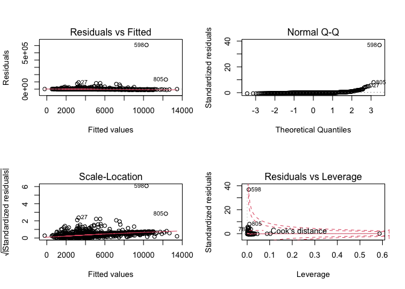

```
##
## Call:
## lm(formula = shares ~ data_channel_is_entertainment + kw_min_min +
##     kw_max_max + kw_avg_max + kw_max_avg + kw_avg_avg + min_positive_polarity,
##     data = dTrain, weights = as.numeric(w))
##
## Weighted Residuals:
##    Min     1Q Median     3Q    Max
##  -5212  -1889  -1187     59  42900
##
## Coefficients:
##                                 Estimate Std. Error t value Pr(>|t|)
## (Intercept)                    1.756e+03  9.419e+02   1.865   0.0624 .
## data_channel_is_entertainment -6.776e+02  2.849e+02  -2.378   0.0175 *
## kw_min_min                     4.239e+00  3.163e+00   1.340   0.1803
## kw_max_max                     2.478e-04  1.115e-03   0.222   0.8241
## kw_avg_max                    -1.216e-03  1.149e-03  -1.058   0.2901
## kw_max_avg                    -6.714e-02  2.958e-02  -2.270   0.0234 *
## kw_avg_avg                     6.953e-01  1.656e-01   4.200 2.81e-05 ***
## min_positive_polarity         -1.245e+03  1.552e+03  -0.802   0.4226
## ---
## Signif. codes:  0 '***' 0.001 '**' 0.01 '*' 0.05 '.' 0.1 ' ' 1
##
## Residual standard error: 4339 on 1695 degrees of freedom
## Multiple R-squared:  0.02174,    Adjusted R-squared:  0.0177
## F-statistic: 5.381 on 7 and 1695 DF,  p-value: 4.103e-06
```

### Non-Linear Models

First, I will fit a simple Regression Tree in order to predict shares. Here is the code below:

```r
set.seed(100)
trctrl <- trainControl(method="repeatedcv", number=10, repeats = 3)
metric = 'RMSE'
tree_fit <- train(shares ~., data = dTrain, method = "rpart", metric = metric, trControl = trctrl,
                 preProcess = c("center", "scale") )
```

I will also fit a bagged tree to predict shares. Here is the code for that:

```r
bag_fit <- train(shares ~., data = dTrain, method = "treebag", metric = metric, trControl = trctrl,
                 preProcess = c("center", "scale") )
```

## Test Set Prediction

I will fit each of the 3 models (Linear Regression, Regression Tree, Bagged Tree) on the test data set.

Here are the corresponding RMSE values:

- The RMSE for the Linear Regression model on the test set is 5415.0648116.
- The RMSE for the Regression Tree model on the test set is 5480.7911326.
- The RMSE for the Bagged Tree model on the test set is 7798.6495045.

## Conclusion

Comparing the linear and non-linear methods based on test MSE, the Linear Regression model performed the best in predicting number of shares, despite having a high MSE and low adjusted R<sup>2</sup> on its own.